# An introduction to Agent-Based Modelling in R

Marco Smolla for FLS R Group, 07 July 2015 @smollamarco

7 July 2015

[Wikipedia](http://en.Wikipedia.org/wiki/agent-based_model): An agent-based model (ABM) is one of a class of computational models for simulating the actions and interactions of autonomous agents with a view to assessing their effects on the system as a whole.

## How can we create autonomous entities?

An agent-based model can be build with the following ingredients:

- **Agents** that interact with the environment or with each other
- **A set of rules** that determines what every agent is allowed or has to do
- **A loop**, which allows to repeatedly act or interact

Here we consider two agents playing a simple game: Rock, Paper, Scissors

## Rock Paper Scissors, simple

At first we need to create our agents

```r
indDF <- data.frame(id=1:2, strategy=NA, num_wins=0)
indDF
```

```
##   id strategy num_wins
## 1  1       NA        0
## 2  2       NA        0
```

That’s already enough to start with. We have now two individuals that we can identify using their **ID**, they have a **strategy** (which they haven’t chosen yet), and an **indicator for success**, here number of winning turns.

In the next step we need to define some rules to let individuals interact with each other

### First: Every individual chooses a strategy

```r
chooseStrategy <- function(ind){
    strats <- sample(x=1:3, size=nrow(ind)) # 1:Paper, 2:Scissors, 3:Rock
    ind$strategy <- strats
    return(ind)
}
```

### Second: Individuals play their strategies

```r
playStrategy <- function(ind){
        c("Paper","Scissors","Rock")
        if(ind$strategy[1]==ind$strategy[2]) {} else{
            #in the case that one chose Rock and the other paper:
            if(any(ind$strategy == 3) && any(ind$strategy == 1)){
                tmp <- ind[ind$strategy==1, "id"]
                ind[tmp,"num_wins"] <- ind[tmp,"num_wins"]+1
            }else{
                #for the two other cases, the better weapon wins:
                tmp <- which(ind[,"strategy"]==max(ind[,"strategy"]))
                ind[tmp,"num_wins"] <- ind[tmp,"num_wins"]+1
            }
        }
    return(ind)
}
```

### Third: Let’s loop it

```r
# indDF <- setup()
# for(i in 1:1000){
    indDF <- chooseStrategy(indDF)#; indDF
    indDF <- playStrategy(indDF)#; indDF
    # i <- i+1
    # }#;indDF
```

At some point it might be handy to have a function for initializing the game

```r
setup <- function(){
    return(data.frame(id=1:2, strategy=NA, num_wins=0))
}
```

That is a neat little model. But say, you would like to get intermediate results of the simulations. How can you monitor the process? Here we will simply return results in every round:

```r
rounds <- 1000
indDF <- setup()
dat <- matrix(NA, rounds, 2)
for(i in 1:rounds){
    indDF <- chooseStrategy(indDF)
    indDF <- playStrategy(indDF)
    dat[i,] <- indDF$num_wins
    i <- i+1
    }
```

And now we can plot the data to see what happened.

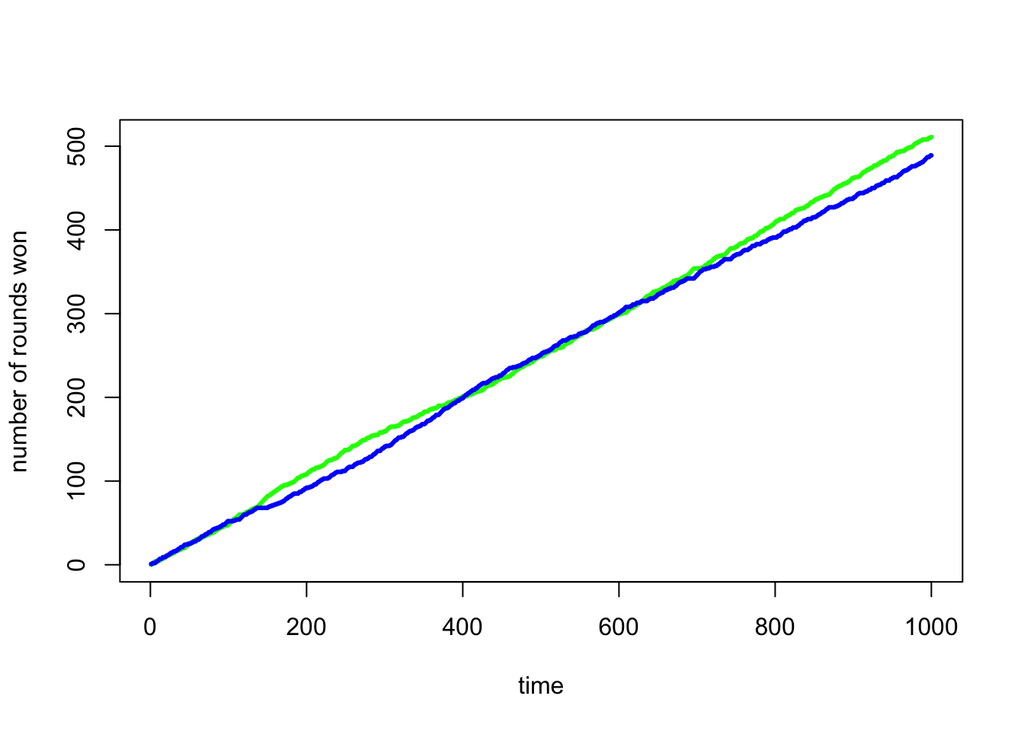

```r
plot(dat[,1], type='l', col='green', lwd=3, xlab='time', ylab='number of rounds won')
lines(dat[,2], col='blue', lwd=3)
```

Alright, and now it becomes interesting. Now, we have a running model and we can start to test a hypothesis. For instance: is a player that never switches it’s strategy more successful?

To test this we need to adjust the strategy choosing function.

```r
chooseStrategy2 <- function(ind){
    strats <- sample(x=1:3, size=1) # 1:Paper, 2:Scissors, 3:Rock
    ind$strategy[2] <- strats
    return(ind)
}
```

Now, the second individual will change its strategy, while the first chooses a strategy once and then sticks with it.

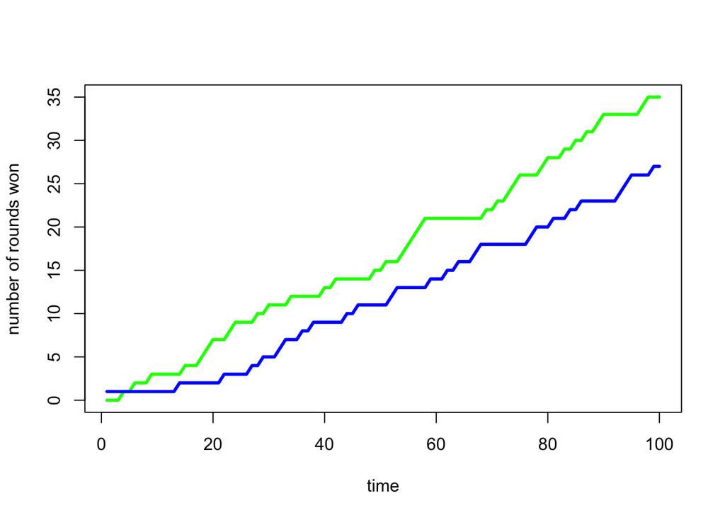

```r
rounds <- 100
repetitions <- 100
dat <- matrix(NA, rounds, 2)
res2 <- c()
for(j in 1:repetitions){
    indDF <- setup()
    indDF[1,"strategy"] <- sample(1:3,1)
    for(i in 1:rounds){
        indDF <- chooseStrategy2(indDF)
        indDF <- playStrategy(indDF)
        dat[i,] <- indDF$num_wins
        i <- i+1
    }
        res2 <- c(res2, which(indDF[,"num_wins"]==max(indDF[,"num_wins"])))
        j <- j+1
}

plot(dat[,1], type='l', col='green', lwd=3, xlab='time', ylab='number of rounds won')
lines(dat[,2], col='blue', lwd=3)
```

```r
# for comparisson let's calculate the winning vector for both players switch strategies:
res1 <- c()
for(j in 1:repetitions){
    indDF <- setup()
    indDF[1,"strategy"] <- sample(1:3,1)
    for(i in 1:rounds){
        indDF <- chooseStrategy(indDF)
        indDF <- playStrategy(indDF)
        dat[i,] <- indDF$num_wins
        i <- i+1
    }
        res1 <- c(res1, which(indDF[,"num_wins"]==max(indDF[,"num_wins"])))
        j <- j+1
}

# and the winner is:
t.test(res1,res2)
```

```
##
##  Welch Two Sample t-test
##
## data:  res1 and res2
## t = -0.609, df = 208.783, p-value = 0.5432
## alternative hypothesis: true difference in means is not equal to 0
## 95 percent confidence interval:
##  -0.17819616  0.09408401
## sample estimates:
## mean of x mean of y
##  1.457944  1.500000
```

So, no, it doesn’t make a difference. Finally, we can go on with our lives without pondering about this question anymore.

## Rock Paper Scissors, network

In this second example we are going to use the same game, but this time several individuals will play against each other. To make it more interesting individuals are organised on a lattice network. Thus, they can only play with their direct neighbors. If they lose, they have to take over the strategy of the winner and vice versa. This can also be seen as a very simple example of an evolutionary process.

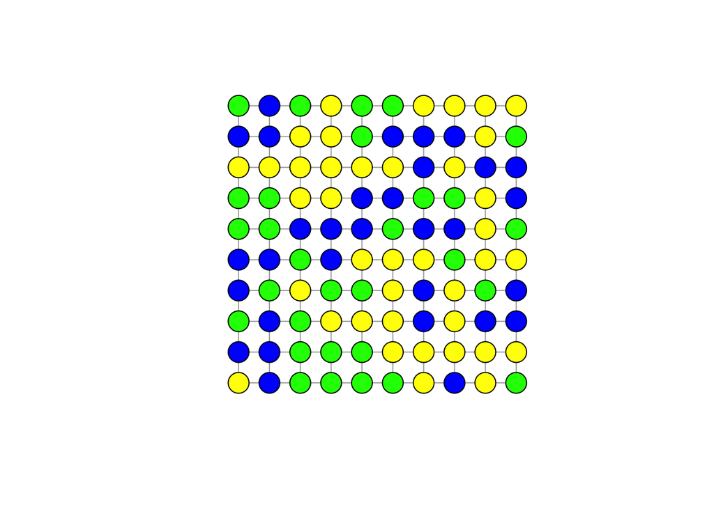

```r
# size of the lattice
sidelength<-10
# creating an empty data.frame to store data
stat<-data.frame()
# creating a lattice network using the igraph package
l<-graph.lattice(length=sidelength,dim=2)
# now every individual chooses a strategy at random
V(l)$weapon<-sample(c(1:3), size=length(V(l)), replace=T)
# for a nicer visualisation lets colour the different options
V(l)[weapon==1]$color<-'blue' # Paper
V(l)[weapon==2]$color<-'yellow' # Scissors
V(l)[weapon==3]$color<-'green' # Rock
# and this is what it looks like:
plot(l, layout=as.matrix(expand.grid(1:sidelength, 1:sidelength)), vertex.label=NA)

for(t in 1:100){
    # pick a random agent ...
    from <- as.numeric(sample(V(l), 1)) # or sample(sidelength^2,1)
    # who are its neighbours?
    nei<-neighbors(l, v=from, mode='all')

    # if there is only one weapon type left
    if(length(unique(V(l)$weapon))==1) {
        # we can either stop the simulation
        stop(paste(c('Paper','Scissors','Rock')[unique(V(l)$weapon)], 'has won the game after',t,'rounds!'))
        # or we let the selected individual choose a different strategy to let the dynamics go on
        # V(l)$weapon[from]<-sample((1:3)[1:3!=as.numeric(V(l)$weapon[from])], 1)
    } else {
        # ... and one of its neighbours
        to <- sample(nei, 1)
        fromto<-c(from,to)
        w<-as.numeric(V(l)$weapon[fromto])
        # if both choices are equal, nothing happens:
        if(w[1]==w[2]) {} else{
            # in the case that one chooses Rock and the other Paper, Paper wins:
            if(max(w) == 3 && min(w) ==1) {
                V(l)$weapon[fromto[w==3]] <- "1"
            }
            else{
                # for the two other cases, the better weapon wins:
                V(l)$weapon[fromto[w==min(w)]] <- V(l)$weapon[fromto[w==max(w)]]
            }
        }

    }
    # let's record the individual abundance of each strategy
    stat<-rbind(stat, c(sum(V(l)$'weapon'=="1"), sum(V(l)$'weapon'=="2"), sum(V(l)$'weapon'=="3")))
    plot(l, layout=as.matrix(expand.grid(1:sidelength, 1:sidelength)), vertex.label=NA)
}
```

```r
names(stat)<-c("Paper","Scissors","Rock")
s<-melt(stat)
```

```
## Using  as id variables
```

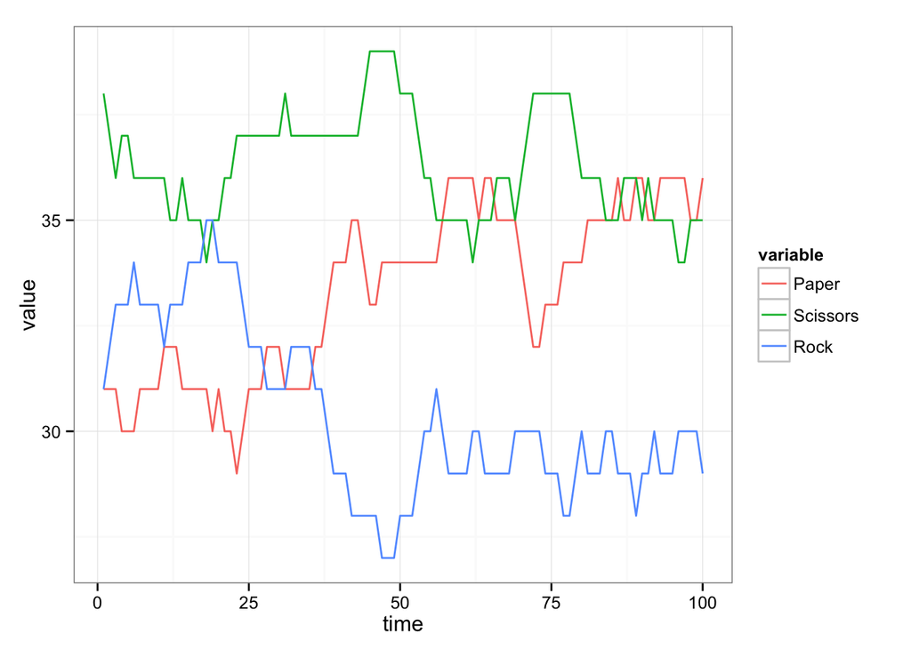

```r
s$time<-1:nrow(stat)
ggplot(data=s, mapping=aes(x=time, y=value, col=variable)) + geom_line() + theme_bw()
```

## And what is with Spock?

With the model above it is very easy for example to add a further strategy. How about adding Spock to the game?

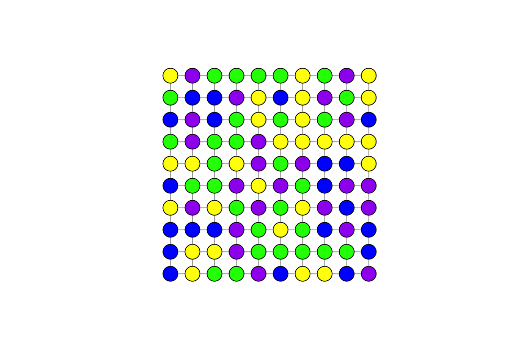

```
## Using  as id variables
```

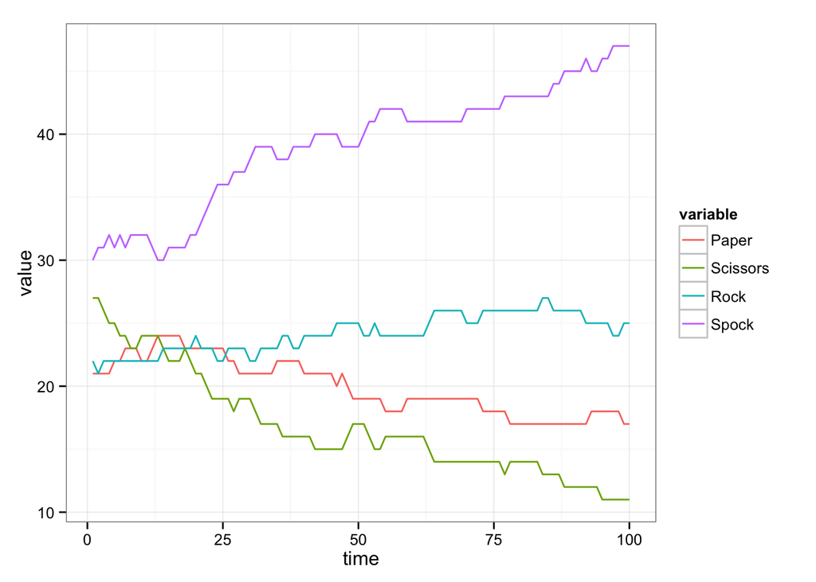